# Red Wine Quality by Riam Abdullah

This report explores a dataset containing quality and chemical properties of red wines for approximately 1599 wines. The dataset consists of 13 variables.

# Univariate Plots Section

```r
names(rw)
```

```
##  [1] "X"                    "fixed.acidity"        "volatile.acidity"
##  [4] "citric.acid"          "residual.sugar"       "chlorides"
##  [7] "free.sulfur.dioxide"  "total.sulfur.dioxide" "density"
## [10] "pH"                   "sulphates"            "alcohol"
## [13] "quality"
```

[output not shown]

```r
str(rw)
```

```
## 'data.frame':    1599 obs. of  13 variables:
##  $ X                   : int  1 2 3 4 5 6 7 8 9 10 ...
##  $ fixed.acidity       : num  7.4 7.8 7.8 11.2 7.4 7.4 7.9 7.3 7.8 7.5 ...
##  $ volatile.acidity    : num  0.7 0.88 0.76 0.28 0.7 0.66 0.6 0.65 0.58 0.5 ...
##  $ citric.acid         : num  0 0 0.04 0.56 0 0 0.06 0 0.02 0.36 ...
##  $ residual.sugar      : num  1.9 2.6 2.3 1.9 1.9 1.8 1.6 1.2 2 6.1 ...
##  $ chlorides           : num  0.076 0.098 0.092 0.075 0.076 0.075 0.069 0.065 0.073 0.071 ...
##  $ free.sulfur.dioxide : num  11 25 15 17 11 13 15 15 9 17 ...
##  $ total.sulfur.dioxide: num  34 67 54 60 34 40 59 21 18 102 ...
##  $ density             : num  0.998 0.997 0.997 0.998 0.998 ...
##  $ pH                  : num  3.51 3.2 3.26 3.16 3.51 3.51 3.3 3.39 3.36 3.35 ...
##  $ sulphates           : num  0.56 0.68 0.65 0.58 0.56 0.56 0.46 0.47 0.57 0.8 ...
##  $ alcohol             : num  9.4 9.8 9.8 9.8 9.4 9.4 9.4 10 9.5 10.5 ...
##  $ quality             : int  5 5 5 6 5 5 5 7 7 5 ...
```

```r
summary(rw)
```

```
##        X          fixed.acidity   volatile.acidity  citric.acid
##  Min.   :   1.0   Min.   : 4.60   Min.   :0.1200   Min.   :0.000
##  1st Qu.: 400.5   1st Qu.: 7.10   1st Qu.:0.3900   1st Qu.:0.090
##  Median : 800.0   Median : 7.90   Median :0.5200   Median :0.260
##  Mean   : 800.0   Mean   : 8.32   Mean   :0.5278   Mean   :0.271
##  3rd Qu.:1199.5   3rd Qu.: 9.20   3rd Qu.:0.6400   3rd Qu.:0.420
##  Max.   :1599.0   Max.   :15.90   Max.   :1.5800   Max.   :1.000
##  residual.sugar     chlorides       free.sulfur.dioxide
##  Min.   : 0.900   Min.   :0.01200   Min.   : 1.00
##  1st Qu.: 1.900   1st Qu.:0.07000   1st Qu.: 7.00
##  Median : 2.200   Median :0.07900   Median :14.00
##  Mean   : 2.539   Mean   :0.08747   Mean   :15.87
##  3rd Qu.: 2.600   3rd Qu.:0.09000   3rd Qu.:21.00
##  Max.   :15.500   Max.   :0.61100   Max.   :72.00
##  total.sulfur.dioxide    density             pH          sulphates
##  Min.   :  6.00       Min.   :0.9901   Min.   :2.740   Min.   :0.3300
##  1st Qu.: 22.00       1st Qu.:0.9956   1st Qu.:3.210   1st Qu.:0.5500
##  Median : 38.00       Median :0.9968   Median :3.310   Median :0.6200
##  Mean   : 46.47       Mean   :0.9967   Mean   :3.311   Mean   :0.6581
##  3rd Qu.: 62.00       3rd Qu.:0.9978   3rd Qu.:3.400   3rd Qu.:0.7300
##  Max.   :289.00       Max.   :1.0037   Max.   :4.010   Max.   :2.0000
##     alcohol         quality
##  Min.   : 8.40   Min.   :3.000
##  1st Qu.: 9.50   1st Qu.:5.000
##  Median :10.20   Median :6.000
##  Mean   :10.42   Mean   :5.636
##  3rd Qu.:11.10   3rd Qu.:6.000
##  Max.   :14.90   Max.   :8.000
```

Our dataset consists of 13 variables, with almost 1599 observations.

Quality will be the main focus of this analysis. I am tryig to analyze which variables can best influence the quality of wine.

```r
summary(rw$quality)
```

```
##    Min. 1st Qu.  Median    Mean 3rd Qu.    Max.
##   3.000   5.000   6.000   5.636   6.000   8.000
```

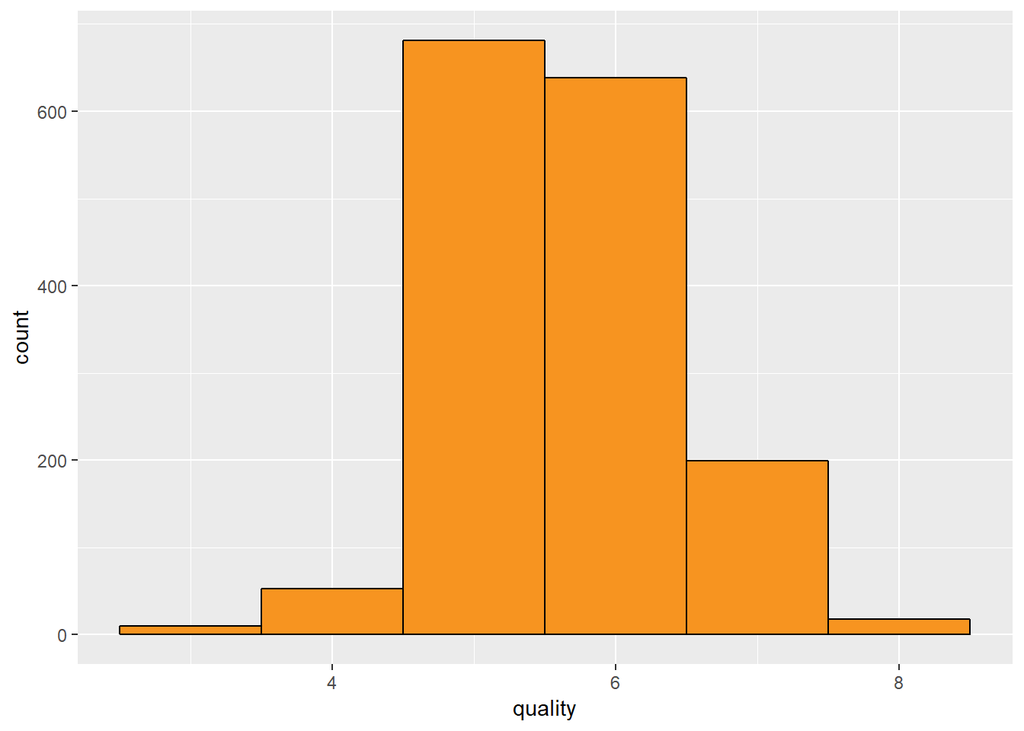

```r
library(ggplot2)
ggplot(aes(x = quality ), data = rw) + geom_histogram(binwidth= 1, color = 'black', fill = '#F79420')
```

The above histogram shows that most of the wines in the dataset are average, with a quality between 5 and 7.

The variable quality is of numeric type int, which is not convenient for the analysis. So first of all, I change the type of the quality variable to factor and add it to the dataframe as a new variable quality.factor. In addition, I create three categories of quality - good (>= 7), bad (<=4), and medium (5 and 6).

```r
rw$quality.factor <- factor(rw$quality)
rw$quality.cat <- NA
rw$quality.cat <- ifelse(rw$quality>=7, 'good', NA)
rw$quality.cat <- ifelse(rw$quality<=4, 'bad', rw$quality.cat)
rw$quality.cat <- ifelse(rw$quality==5, 'medium', rw$quality.cat)
rw$quality.cat <- ifelse(rw$quality==6, 'medium', rw$quality.cat)

rw$quality.cat <- factor(rw$quality.cat, levels = c("bad", "medium", "good"))
```

Now, Let’s do the following for all variables.

- Print Summary.

*Histogram.

- If the varible doesn’t have a normal distribution, I will add a log10 for that varible.

# Fixed Acidity

```r
summary(rw$fixed.acidity)
```

```
##    Min. 1st Qu.  Median    Mean 3rd Qu.    Max.
##    4.60    7.10    7.90    8.32    9.20   15.90
```

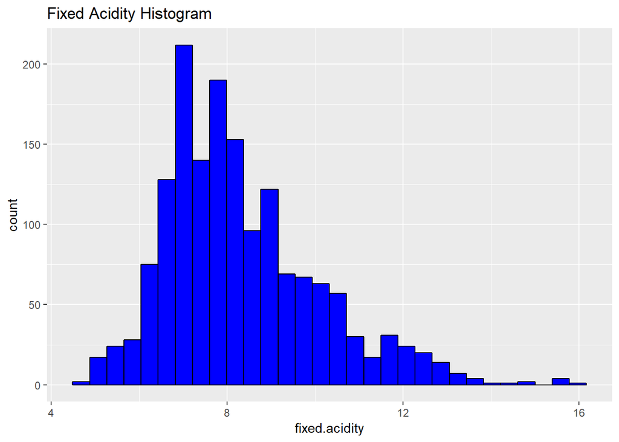

```r
ggplot(aes(x = fixed.acidity), data = rw) + geom_histogram(color = 'black', fill = 'blue') + ggtitle('Fixed Acidity Histogram')
```

The median is around 7.9 with high concentration of wines with Fixed Acidity.

# Volatile Acidity

```r
summary(rw$volatile.acidity)
```

```
##    Min. 1st Qu.  Median    Mean 3rd Qu.    Max.
##  0.1200  0.3900  0.5200  0.5278  0.6400  1.5800
```

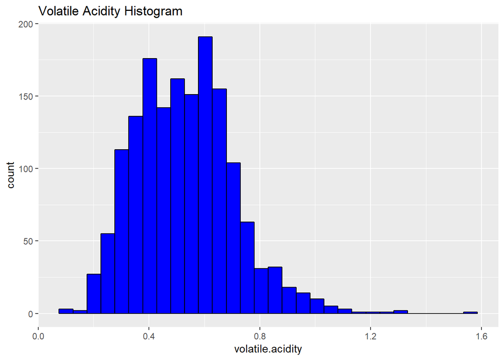

```r
ggplot(aes(x = volatile.acidity), data = rw) + geom_histogram(color = 'black', fill = 'blue') + ggtitle('Volatile Acidity Histogram')
```

Volatile acidity distribution looks like Bimodal with two peaks around 0.4 and 0.6.

# Citric Acid

```r
summary(rw$citric.acid)
```

```
##    Min. 1st Qu.  Median    Mean 3rd Qu.    Max.
##   0.000   0.090   0.260   0.271   0.420   1.000
```

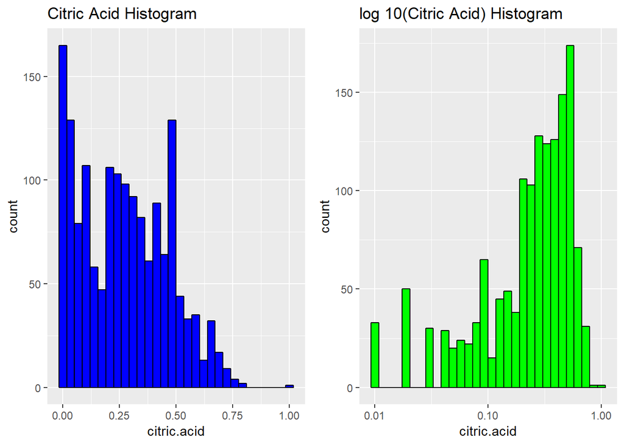

```r
library(gridExtra)
p1 <- ggplot(aes(x = citric.acid), data = rw) + geom_histogram(color = 'black', fill = 'blue') + ggtitle('Citric Acid Histogram')

p2 <- ggplot(aes(x = citric.acid), data = rw) + geom_histogram(color = 'black', fill = 'green') + ggtitle('log 10(Citric Acid) Histogram') + scale_x_log10()

grid.arrange(p1, p2, ncol=2)
```

Citric Acid distribution looks strange and Some higher values have no data, even after we use log 10 it doesn’t transform to be normal distibution.

# Residual Sugar

```r
summary(rw$residual.sugar)
```

```
##    Min. 1st Qu.  Median    Mean 3rd Qu.    Max.
##   0.900   1.900   2.200   2.539   2.600  15.500
```

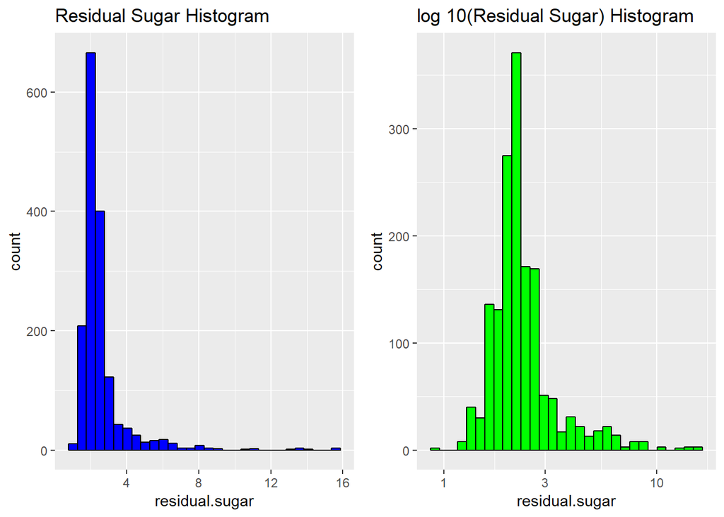

```r
p1 <- ggplot(aes(x = residual.sugar), data = rw) + geom_histogram(color = 'black', fill = 'blue') + ggtitle('Residual Sugar Histogram')

p2 <- ggplot(aes(x = residual.sugar), data = rw) + geom_histogram(color = 'black', fill = 'green') + ggtitle('log 10(Residual Sugar) Histogram') + scale_x_log10()

grid.arrange(p1, p2, ncol=2)
```

Residual Sugar distribution is positively skewed with Median at around 2.2.

# Chlorides

```r
summary(rw$chlorides)
```

```
##    Min. 1st Qu.  Median    Mean 3rd Qu.    Max.
## 0.01200 0.07000 0.07900 0.08747 0.09000 0.61100
```

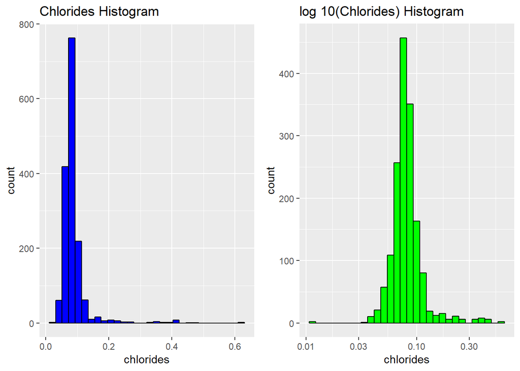

```r
p1 <- ggplot(aes(x = chlorides), data = rw) + geom_histogram(color = 'black', fill = 'blue') + ggtitle('Chlorides Histogram')

p2 <- ggplot(aes(x = chlorides), data = rw) + geom_histogram( color = 'black', fill = 'green') + ggtitle('log 10(Chlorides) Histogram') + scale_x_log10()

grid.arrange(p1, p2, ncol=2)
```

# Free Sulfur Dioxide

```r
summary(rw$free.sulfur.dioxide)
```

```
##    Min. 1st Qu.  Median    Mean 3rd Qu.    Max.
##    1.00    7.00   14.00   15.87   21.00   72.00
```

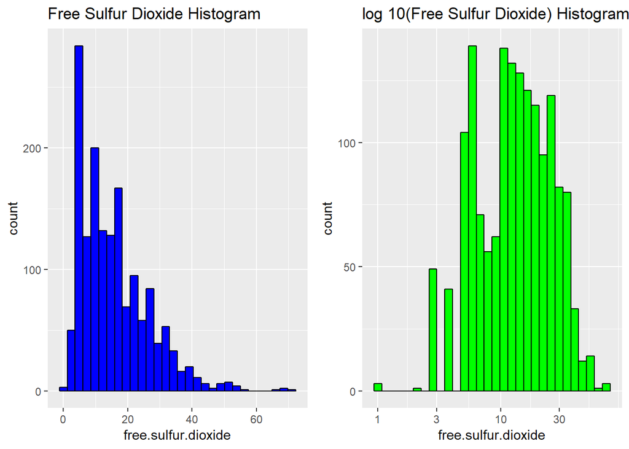

```r
p1 <- ggplot(aes(x = free.sulfur.dioxide), data = rw) + geom_histogram(color = 'black', fill = 'blue') + ggtitle('Free Sulfur Dioxide Histogram')

p2 <- ggplot(aes(x = free.sulfur.dioxide), data = rw) + geom_histogram(color = 'black', fill = 'green') + ggtitle('log 10(Free Sulfur Dioxide) Histogram') + scale_x_log10()

grid.arrange(p1, p2, ncol=2)
```

# Total Sulfur Dioxide

```r
summary(rw$total.sulfur.dioxide)
```

```
##    Min. 1st Qu.  Median    Mean 3rd Qu.    Max.
##    6.00   22.00   38.00   46.47   62.00  289.00
```

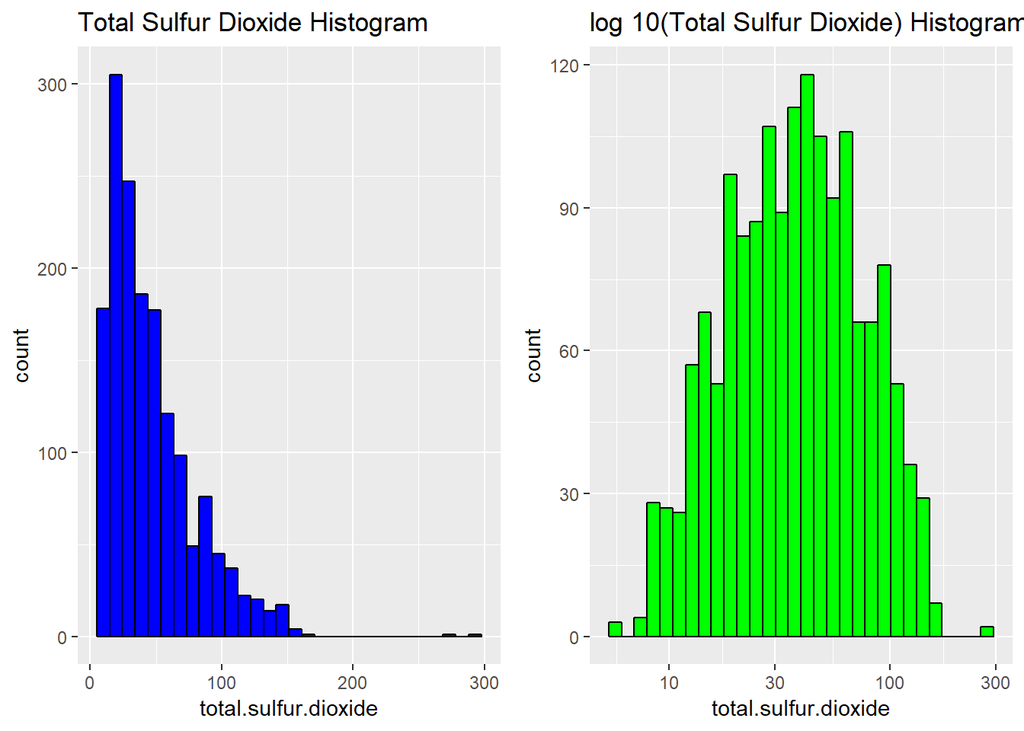

```r
p1 <- ggplot(aes(x = total.sulfur.dioxide), data = rw) + geom_histogram(color = 'black', fill = 'blue') + ggtitle('Total Sulfur Dioxide Histogram')

p2 <- ggplot(aes(x = total.sulfur.dioxide), data = rw) + geom_histogram(color = 'black', fill = 'green') + ggtitle('log 10(Total Sulfur Dioxide) Histogram') + scale_x_log10()

grid.arrange(p1, p2, ncol=2)
```

# Density

```r
summary(rw$density)
```

```
##    Min. 1st Qu.  Median    Mean 3rd Qu.    Max.
##  0.9901  0.9956  0.9968  0.9967  0.9978  1.0037
```

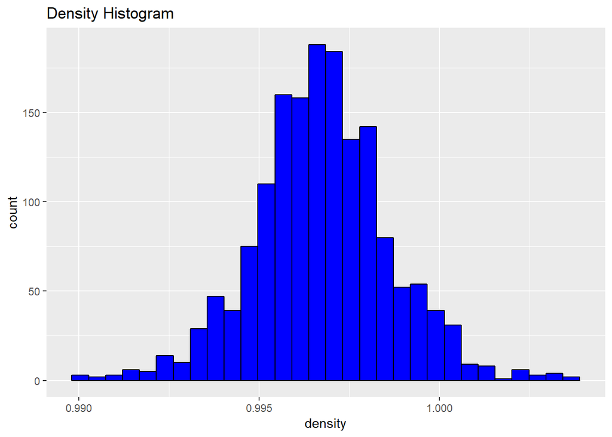

```r
ggplot(aes(x = density), data = rw) + geom_histogram(color = 'black', fill = 'blue') + ggtitle('Density Histogram')
```

# pH

```r
summary(rw$pH)
```

```
##    Min. 1st Qu.  Median    Mean 3rd Qu.    Max.
##   2.740   3.210   3.310   3.311   3.400   4.010
```

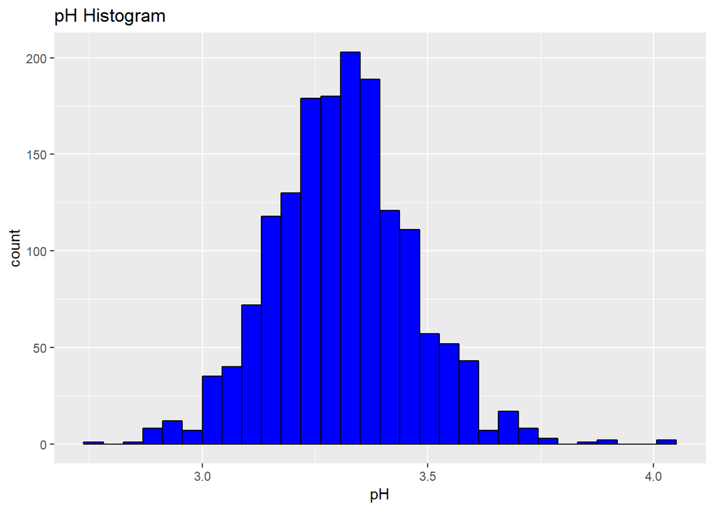

```r
ggplot(aes(x = pH), data = rw) + geom_histogram(color = 'black', fill = 'blue') + ggtitle('pH Histogram')
```

# Sulphates

```r
summary(rw$sulphates)
```

```
##    Min. 1st Qu.  Median    Mean 3rd Qu.    Max.
##  0.3300  0.5500  0.6200  0.6581  0.7300  2.0000
```

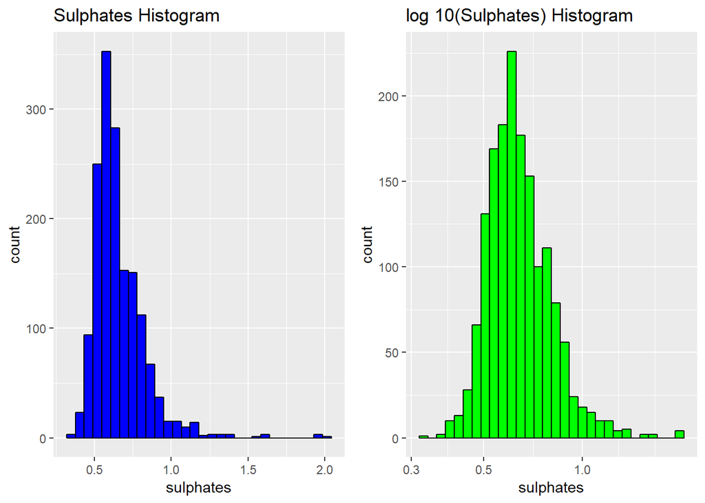

```r
p1 <- ggplot(aes(x = sulphates), data = rw) + geom_histogram(color = 'black', fill = 'blue') + ggtitle('Sulphates Histogram')

p2 <- ggplot(aes(x = sulphates), data = rw) + geom_histogram( color = 'black', fill = 'green') + ggtitle('log 10(Sulphates) Histogram') + scale_x_log10()

grid.arrange(p1, p2, ncol=2)
```

# Alcohol

```r
summary(rw$alcohol)
```

```
##    Min. 1st Qu.  Median    Mean 3rd Qu.    Max.
##    8.40    9.50   10.20   10.42   11.10   14.90
```

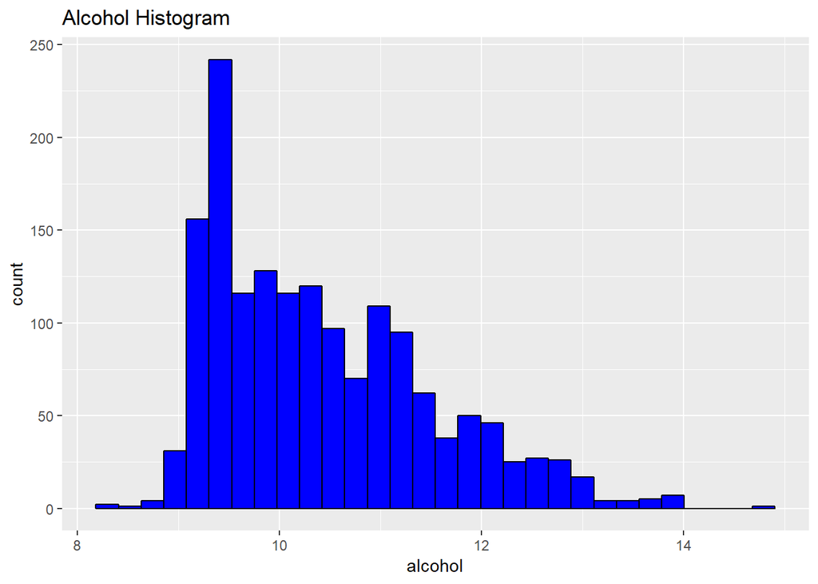

```r
ggplot(aes(x = alcohol), data = rw) + geom_histogram(color = 'black', fill = 'blue') + ggtitle('Alcohol Histogram')
```

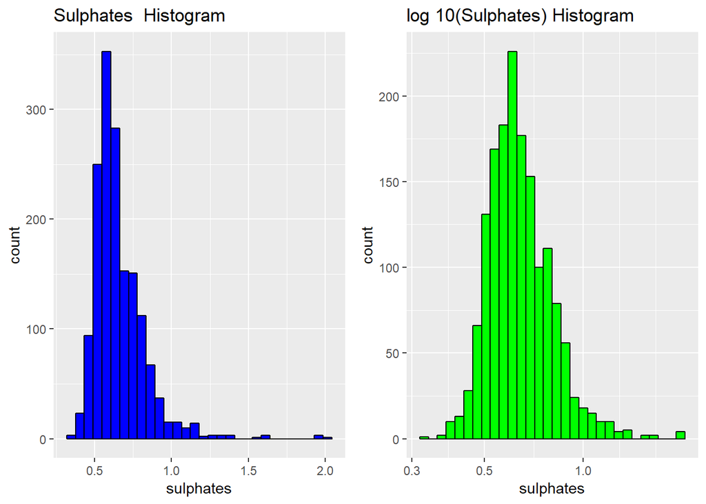

```r
p1 <- ggplot(aes(x = sulphates ), data = rw) + geom_histogram(color = 'black', fill = 'blue') + ggtitle('Sulphates  Histogram')

p2 <- ggplot(aes(x = sulphates), data = rw) + geom_histogram( color = 'black', fill = 'green') + ggtitle('log 10(Sulphates) Histogram') + scale_x_log10()

grid.arrange(p1, p2, ncol=2)
```

I transform all this data using the log10-transformation to make the data look more like normal distribution.

# Univariate Analysis

### What is/are the main feature(s) of interest in your dataset?

The main feature of interest in this dataset is the ‘quality’.

### What other features in the dataset do you think will help support your investigation into your feature(s) of interest?

I think Alcohol concentration can be used to determine quality of wine.Acidity (fixed, volatile or citric) values may change the quality of wine, pH and sulphates may also have some effect on the quality. Residual Sugar may have an effect on the taste of the wine.

### Did you create any new variables from existing variables in the dataset?

I have created quality.cat as my new variables from wine quality and quality.factor.

### Of the features you investigated, were there any unusual distributions? Did you perform any operations on the data to tidy, adjust, or change the form of the data? If so, why did you do this?

I add log 10 scales to the varibles that doesn’t have normal distribution (residual.sugar, chlorides, free.sulfur.dioxide, total.sulfur.dioxide and sulphates.). all these varible have a normal or close to normal distribution.

# Bivariate Plots Section and Analysis

In this section, I analyse relationships between wine characteristics and its perceived quality, as well as possible correlations between different characteristics.

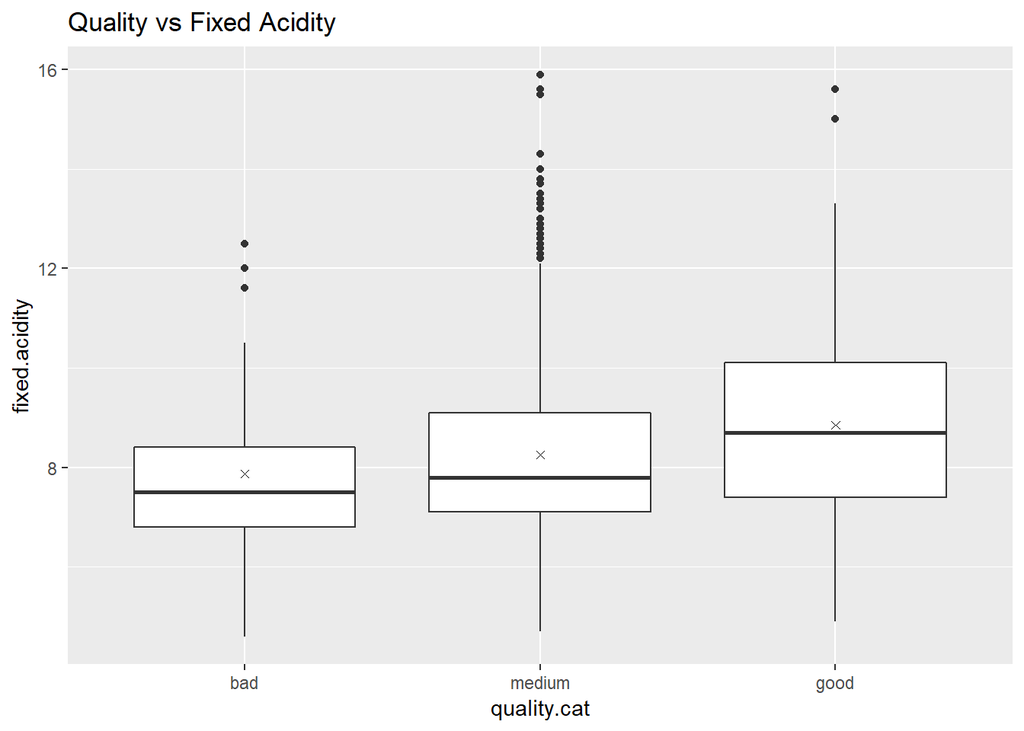

```r
ggplot(aes(x=quality.cat, y=fixed.acidity), data = rw) + geom_boxplot() + stat_summary(fun.y="mean", geom = 'point', shape = 4) + ggtitle('Quality vs Fixed Acidity')
```

The X point in the above plot represent the mean for each quality number.

The quality increases with increasing values of fixed.acidity variable.

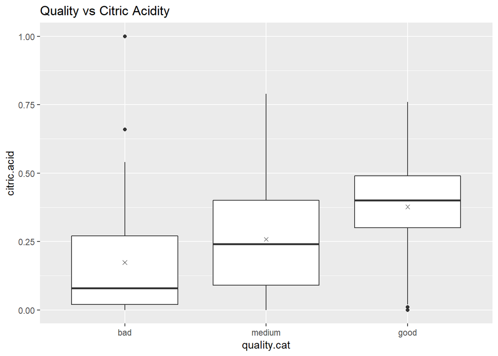

```r
ggplot(aes(x=quality.cat, y=citric.acid), data = rw) + geom_boxplot() + stat_summary(fun.y="mean", geom = 'point', shape = 4) + ggtitle('Quality vs Citric Acidity')
```

The quality increases with increasing values of citric.acid variable.

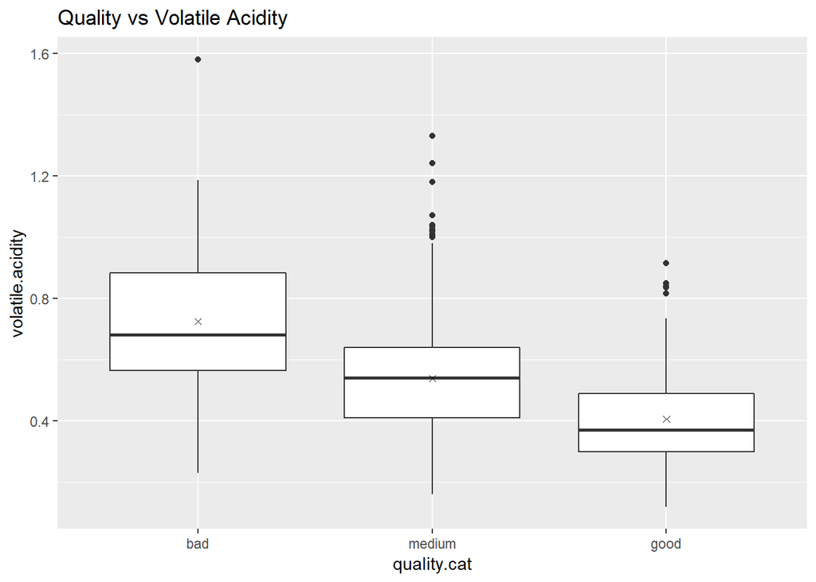

```r
ggplot(aes(x=quality.cat, y=volatile.acidity), data = rw) + geom_boxplot() + stat_summary(fun.y="mean", geom = 'point', shape = 4) + ggtitle('Quality vs Volatile Acidity')
```

The quality decrease with increasing values of volatile.acidity variable.

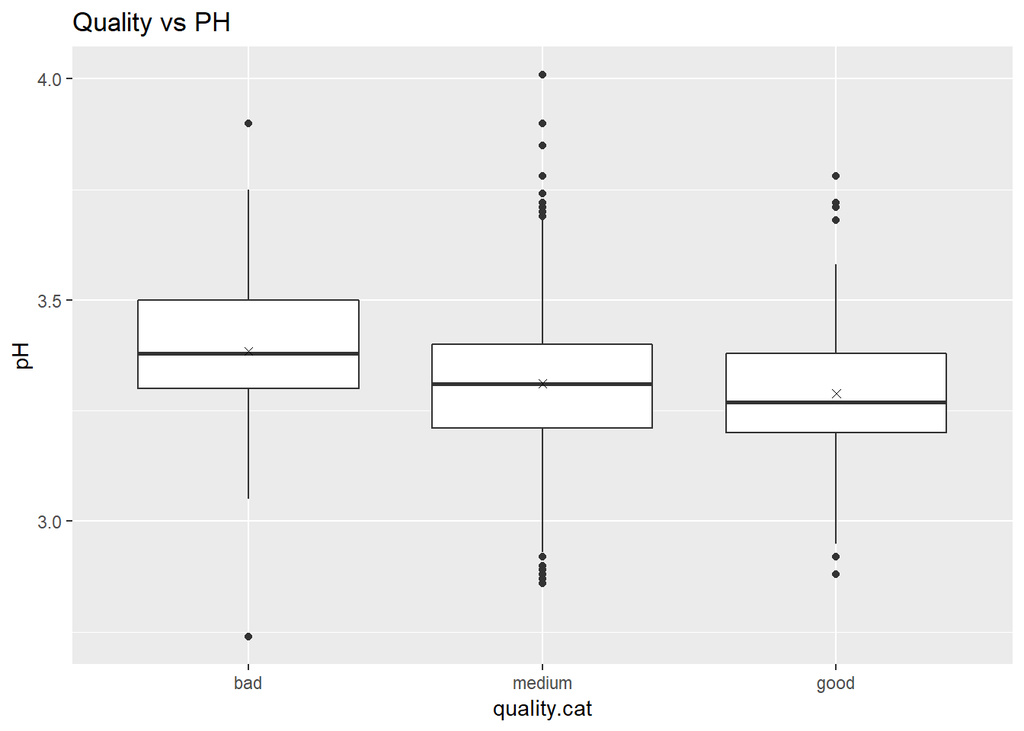

```r
ggplot(aes(x=quality.cat, y=pH), data = rw) + geom_boxplot() + stat_summary(fun.y="mean", geom = 'point', shape = 4) + ggtitle('Quality vs PH')
```

The quality decrease with increasing values of pH variable.

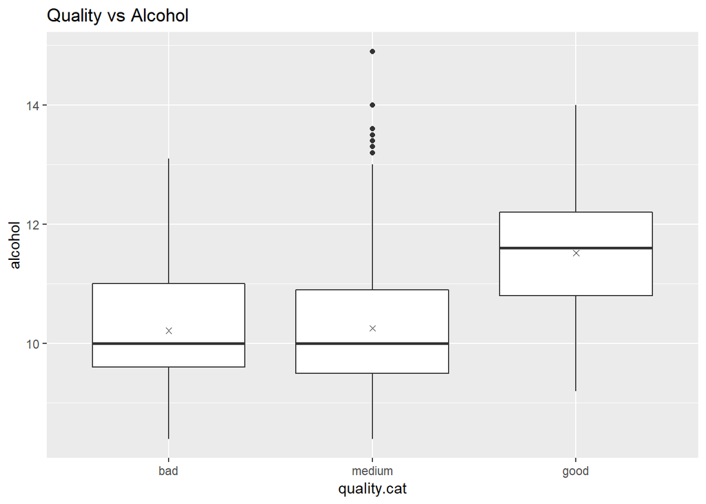

```r
ggplot(aes(x=quality.cat, y=alcohol), data = rw) + geom_boxplot() + stat_summary(fun.y="mean", geom = 'point', shape = 4) + ggtitle('Quality vs Alcohol')
```

The quality increase with increasing values of alcohol variable.

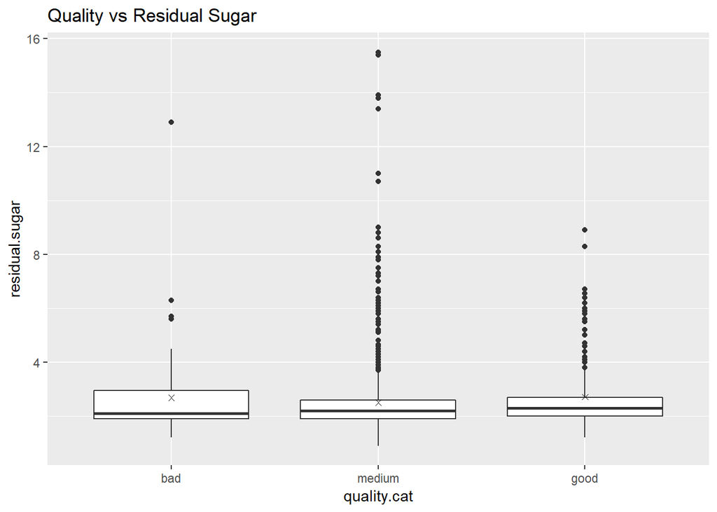

```r
ggplot(aes(x=quality.cat, y=residual.sugar), data = rw) + geom_boxplot() + stat_summary(fun.y="mean", geom = 'point', shape = 4) + ggtitle('Quality vs Residual Sugar')
```

Residual Sugar almost has no effect on the quality of the wine.

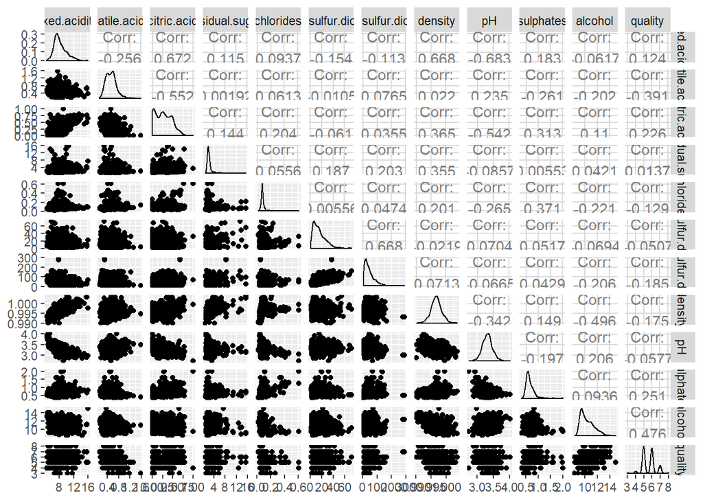

```r
rw.subset <- rw[,2:13]
ggpairs(rw.subset)
```

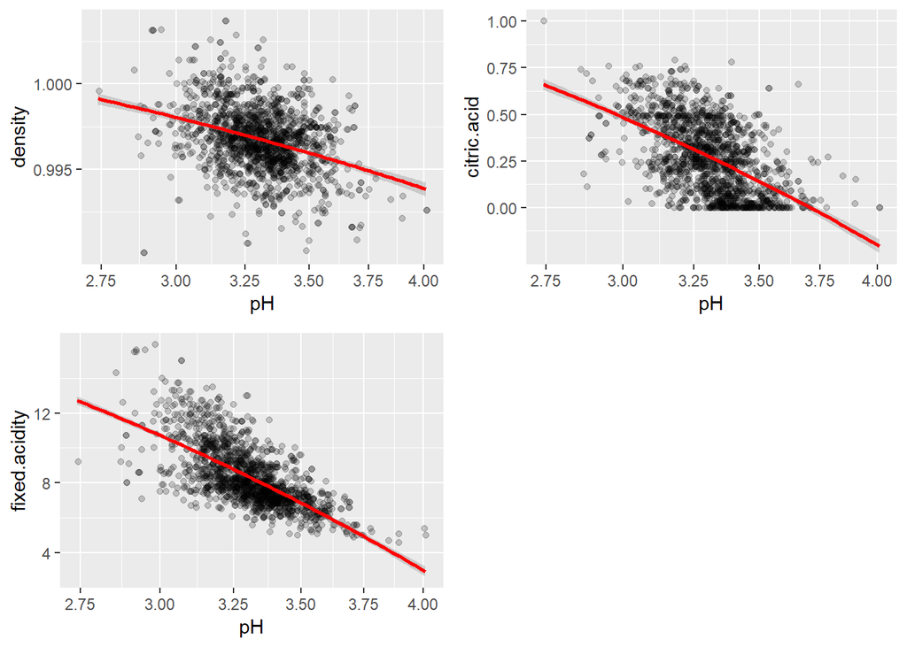

```r
dens <- ggplot(aes(x = pH, y = density), data = rw) +
  geom_point(alpha = 1/5, position = position_jitter(h = 0)) +
  coord_trans(x = "log10") +
  geom_smooth(method = "lm", color = "red")

citr.ac <- ggplot(aes(x = pH, y = citric.acid), data = rw) +
  geom_point(alpha = 1/5, position = position_jitter(h = 0)) +
  coord_trans(x = "log10") +
  geom_smooth(method = "lm", color = "red")

fix.ac <- ggplot(aes(x = pH, y = fixed.acidity), data = rw) +
  geom_point(alpha = 1/5, position = position_jitter(h = 0)) +
  coord_trans(x = "log10") +
  geom_smooth(method = "lm", color = "red")

grid.arrange(dens, citr.ac, fix.ac, ncol = 2)
```

The highest positive correlation, according to a ggpairs matrix, is between density and fixed.acidity, as well as between fixed.acidity and citric.acid.

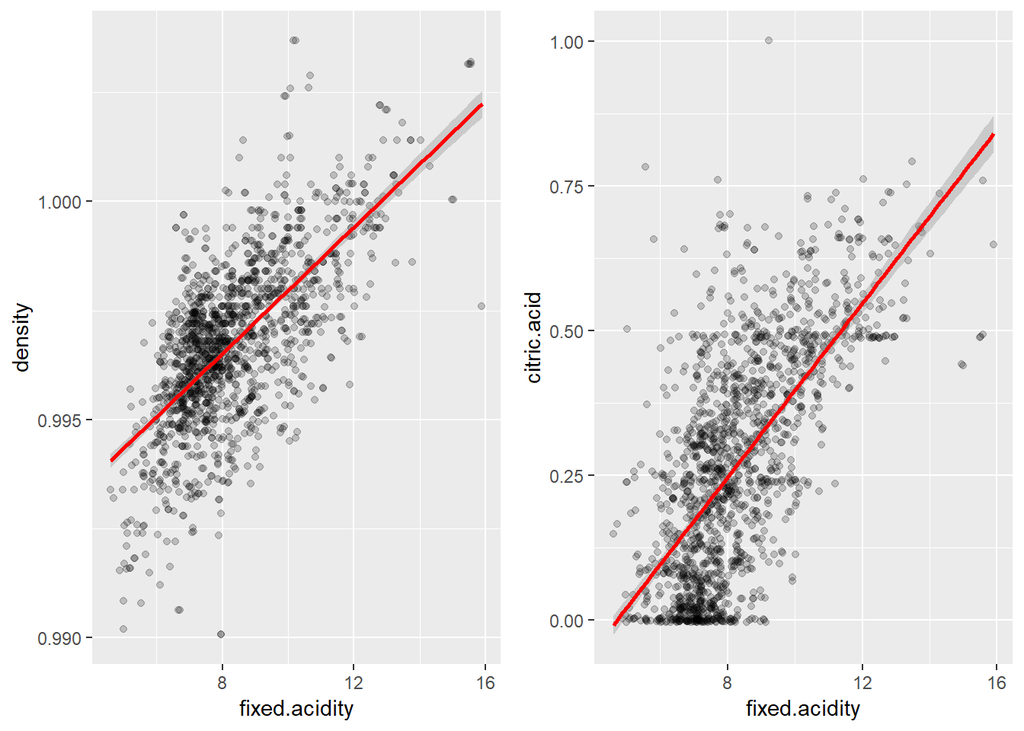

```r
pos1 <- ggplot(aes(x = fixed.acidity, y = density), data = rw) +
  geom_jitter(alpha = 1/5) +
  geom_smooth(method = "lm", color = "red")

pos2 <- ggplot(aes(x = fixed.acidity, y = citric.acid), data = rw) +
  geom_jitter(alpha = 1/5) +
  geom_smooth(method = "lm", color = "red")

grid.arrange(pos1, pos2, ncol = 2)
```

### Talk about some of the relationships you observed in this part of the investigation. How did the feature(s) of interest vary with other features in the dataset?

### Did you observe any interesting relationships between the other features (not the main feature(s) of interest)?

### What was the strongest relationship you found?

1. Fixed Acidity and Citric Acid seems to have a positive correlation with the quality.
2. Volatile Acidity seems to have a negative correlation with the quality.
3. Better wines seem to have higher concentration of Citric Acid.
4. Better wines seem to have higher alcohol percentages.
5. pH seems to have a negative correlation with the quality.
6. Better wines seem to be more acidic.
7. Residual sugar almost has no effect on the wine quality.

# Multivariate Plots Section and Analysis

We saw in above analysis that alcohol plays a strong part in the quality of the wine. I will first make alcohol constant and try to insert a few more variables to see if they contribute to the overall quality in any other way.

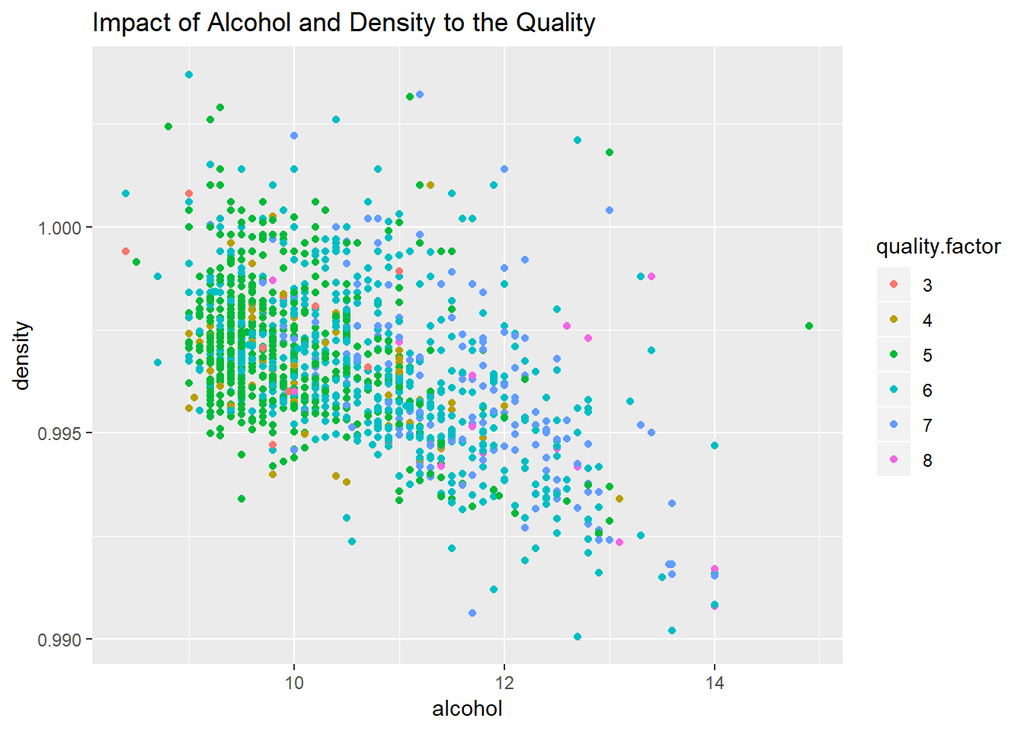

```r
ggplot(aes(x = alcohol, y= density), data = rw) + geom_point(aes(color = quality.factor)) + ggtitle('Impact of Alcohol and Density to the Quality')
```

Density does not show prominent part in changing the wine quality. It seems like that the density correlation with quality we were seeing earlier was due to alcohol percent.

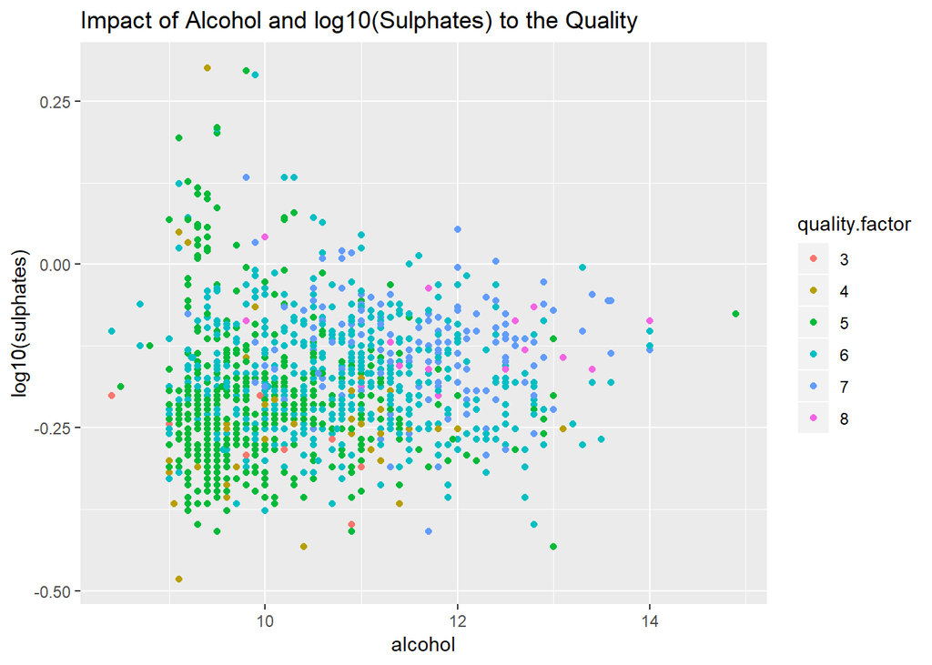

```r
ggplot(aes(x = alcohol, y= log10(sulphates)), data = rw) + geom_point(aes(color = quality.factor)) + ggtitle('Impact of Alcohol and log10(Sulphates) to the Quality')
```

Wines with higher alcohol content produce better wine quality if they have higher level of Sulphates.

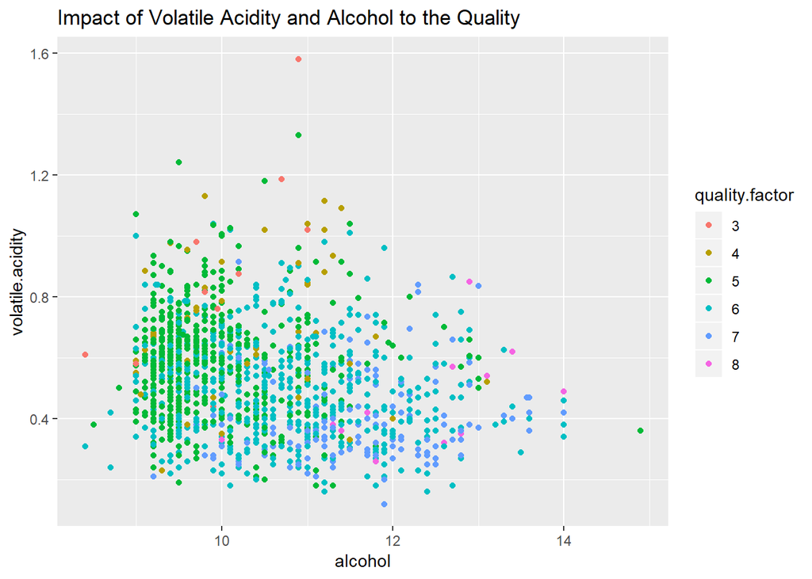

```r
ggplot(aes(x = alcohol, y= volatile.acidity), data = rw) + geom_point(aes(color = quality.factor)) + ggtitle('Impact of Volatile Acidity and Alcohol to the Quality')
```

Volatile acid has just the opposite effect. Wines with higher alcohol content produce better wine quality if they have low concentration of volatile acid.

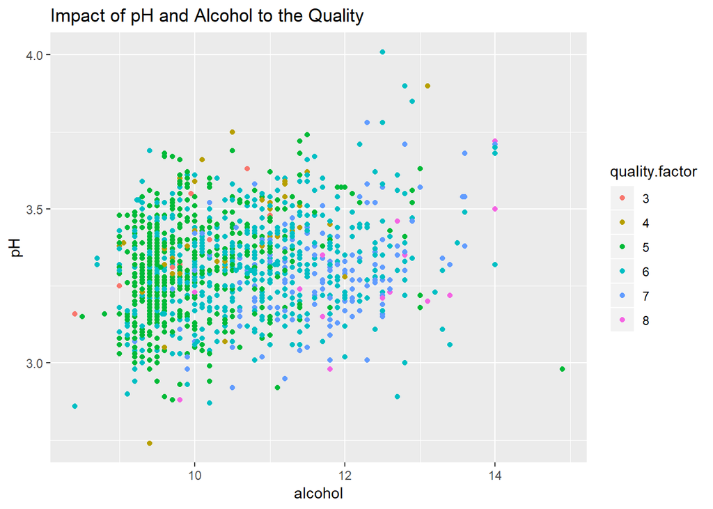

```r
ggplot(aes(x = alcohol, y= pH), data = rw) + geom_point(aes(color = quality.factor)) + ggtitle('Impact of pH and Alcohol to the Quality')
```

Low pH and high Alcohol percentage seems to produce better wines.

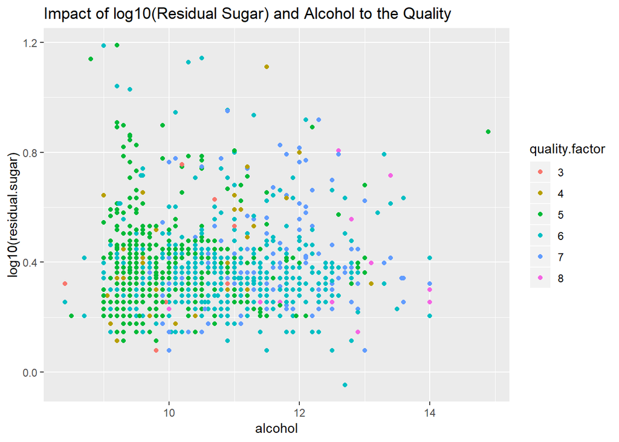

```r
ggplot(aes(x = alcohol, y= log10(residual.sugar)), data = rw) + geom_point(aes(color = quality.factor)) + ggtitle('Impact of log10(Residual Sugar) and Alcohol to the Quality')
```

It seems that residual sugar has no effect on quality.

Now, I am going to investigate the influence of Acids on the quality of Wines.

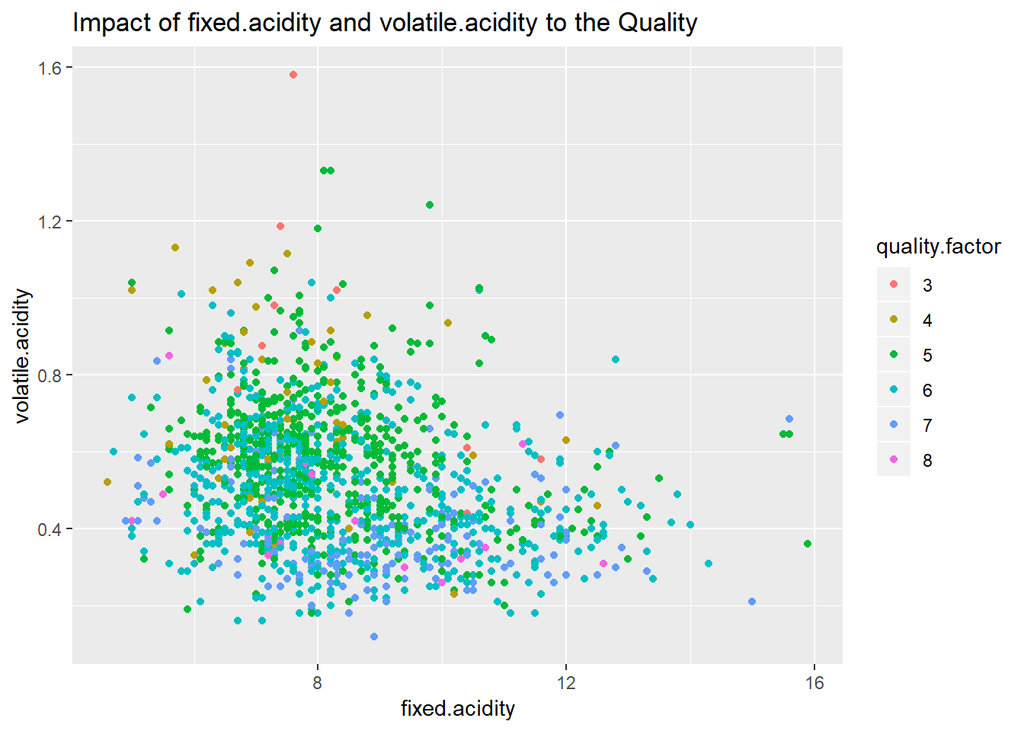

```r
ggplot(aes(x = fixed.acidity, y= volatile.acidity), data = rw) + geom_point(aes(color = quality.factor)) + ggtitle('Impact of fixed.acidity and volatile.acidity to the Quality')
```

It seems that there is no correlations with the quality here.

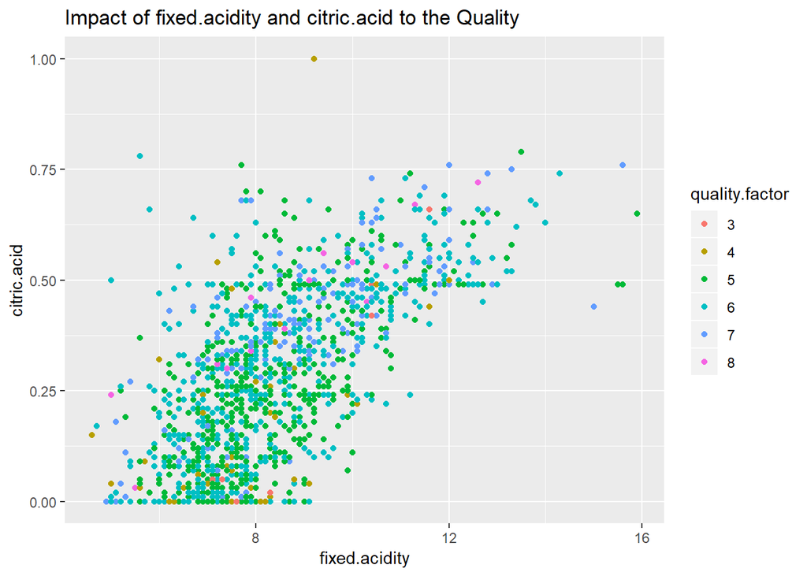

```r
ggplot(aes(x = fixed.acidity, y= citric.acid), data = rw) + geom_point(aes(color = quality.factor)) + ggtitle('Impact of fixed.acidity and citric.acid to the Quality')
```

It seems that there is no correlations with the quality here.

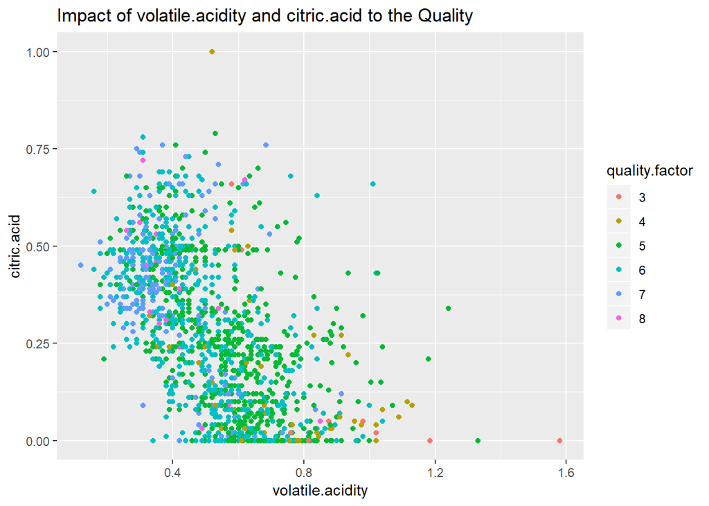

```r
ggplot(aes(x = volatile.acidity, y= citric.acid), data = rw) + geom_point(aes(color = quality.factor)) + ggtitle('Impact of volatile.acidity and citric.acid to the Quality')
```

Higher Citric Acid and low Volatile Acid seems to produce better Wines.

### Talk about some of the relationships you observed in this part of the investigation. Were there features that strengthened each other in terms of looking at your feature(s) of interest?

High Alcohol and Sulaphate content seems to produce better wines. Citric Acid, even though weakly correlated plays a part in improving the wine quality.

### Were there any interesting or surprising interactions between features?

Higher Citric Acid and low Volatile Acid seems to produce better Wines.

### OPTIONAL: Did you create any models with your dataset? Discuss the strengths and limitations of your model.

# Final Plots and Summary

### Plot One

[figure not shown]